# CodeBook/Data Dictionary

JLR

1/8/2021

### PURPOSE

This document describes the data layout of the “tidy” data set generated by the *run_analysis()* R program. The data to be analyzed will be downloaded from the [UCI Machine Learning Repository](http://archive.ics.uci.edu/ml/datasets/Human+Activity+Recognition+Using+Smartphones). The data used to generated the output dataset is stored in a .zip file which includes the following key files:

- ‘train/X_train.txt’: Training set of sensor observations
- ‘train/y_train.txt’: Training activity indices which are mapped to ‘activity_labels.txt’.
- ‘test/X_test.txt’: Test set of sensor observations
- ‘test/y_test.txt’: Test activity indices which are mapped to ‘activity_labels.txt’.
- ‘test/subject_test.txt’: Each row identifies the subject who performed the activity for each window sample. Its range is from 1 to 30.
- ‘train/subject_train.txt’: Each row identifies the subject who performed the activity for each window sample. Its range is from 1 to 30.

The /train and /test folders provide the data to be analyzed. Each row in the files provides:

- Triaxial acceleration from the accelerometer (total acceleration) and the estimated body acceleration.
- Triaxial Angular velocity from the gyroscope.
- A 561-feature vector with time and frequency domain variables.
- Numeric index to the daily activities (indexed in the ‘activity_labels.txt’ dataset).
- A numeric identifier of the subject who carried out the experiment.

The diagram below provides a high-level flow of the key input files.

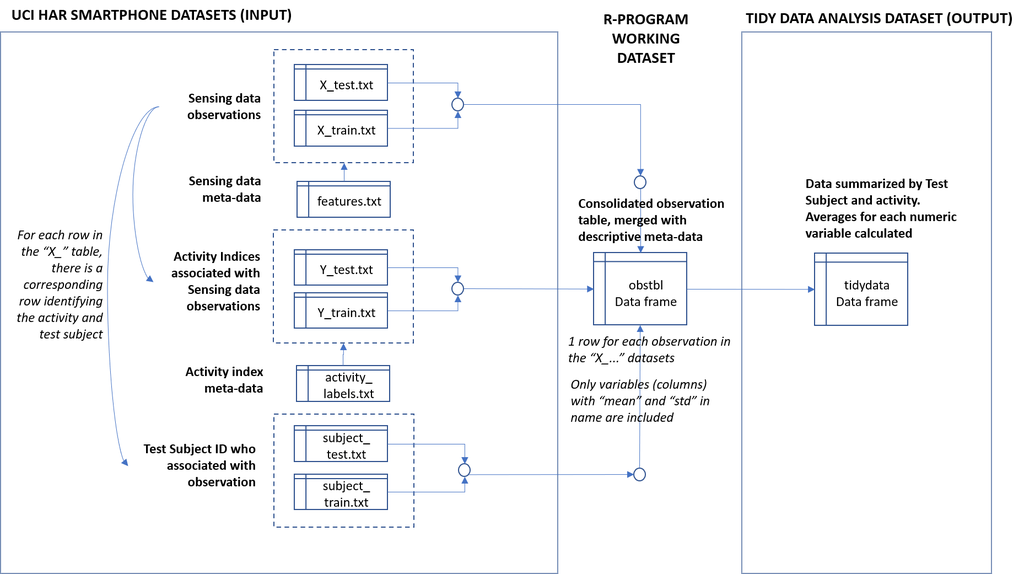

DataFlow

### DATA DEFINITIONS FOR TIDY DATA ANALYSIS DATASET (OUTPUT)

The output dataset is a summary of the detailed observations. The observations are summarized by Test Subject (the person who was wearing sensing device) and Activity. A mean calculation is prepared for each variable at the summary level.

```r
cb <- read.csv("CodeBook.csv", header=TRUE)
knitr::kable(cb
             )
```

| ï..Variable.Name | Type | Description | Units | Domain.of.Values |
| --- | --- | --- | --- | --- |
| subject | Integer | A unique number which identifies each person who participated in the experiment | None | An integer number > 0 |
| activity | Categorical | A descriptive word or phrase that identifies the type of daily physical routine that a test subject is performing when the observation measurements are taken | None | WALKING, WALKING_UPSTAIRS, WALKING_DOWNSTAIRS,SITTING, STANDING, LAYING |
| tbodyaccmeanx | Numeric, double | A mean measurement of a time domain accelerometer in the X-axis. | Hz | NA |
| tbodyaccmeany | Numeric, double | A mean measurement of a time domain accelerometer in the Y-axis. | Hz | NA |
| tbodyaccmeanz | Numeric, double | A mean measurement of a time domain accelerometer in the Z-axis. | Hz | NA |
| tbodyaccstdx | Numeric, double | A standard deviation measurement of a time domain accelerometer in the X-axis. | Hz | NA |
| tbodyaccstdy | Numeric, double | A standard deviation measurement of a time domain accelerometer in the Y-axis. | Hz | NA |
| tbodyaccstdz | Numeric, double | A standard deviation measurement of a time domain accelerometer in the Z-axis. | Hz | NA |
| tgravityaccmeanx | Numeric, double | A mean measurement of a time domain accelerometer in the X-axis. | Hz | NA |
| tgravityaccmeany | Numeric, double | A mean measurement of a time domain accelerometer in the Y-axis. | Hz | NA |
| tgravityaccmeanz | Numeric, double | A mean measurement of a time domain accelerometer in the Z-axis. | Hz | NA |
| tgravityaccstdx | Numeric, double | A standard deviation measurement of a time domain accelerometer in the X-axis. | Hz | NA |
| tgravityaccstdy | Numeric, double | A standard deviation measurement of a time domain accelerometer in the Y-axis. | Hz | NA |
| tgravityaccstdz | Numeric, double | A standard deviation measurement of a time domain accelerometer in the Z-axis. | Hz | NA |
| tbodyaccjerkmeanx | Numeric, double | A mean measurement of a time domain accelerometer in the X-axis. | Hz | NA |
| tbodyaccjerkmeany | Numeric, double | A mean measurement of a time domain accelerometer in the Y-axis. | Hz | NA |
| tbodyaccjerkmeanz | Numeric, double | A mean measurement of a time domain accelerometer in the Z-axis. | Hz | NA |
| tbodyaccjerkstdx | Numeric, double | A standard deviation measurement of a time domain accelerometer in the X-axis. | Hz | NA |
| tbodyaccjerkstdy | Numeric, double | A standard deviation measurement of a time domain accelerometer in the Y-axis. | Hz | NA |
| tbodyaccjerkstdz | Numeric, double | A standard deviation measurement of a time domain accelerometer in the Z-axis. | Hz | NA |
| tbodygyromeanx | Numeric, double | A mean measurement of a time domain gyroscope in the X-axis. | Hz | NA |
| tbodygyromeany | Numeric, double | A mean measurement of a time domain gyroscope in the Y-axis. | Hz | NA |
| tbodygyromeanz | Numeric, double | A mean measurement of a time domain gyroscope in the Z-axis. | Hz | NA |
| tbodygyrostdx | Numeric, double | A standard deviation measurement of a time domain gyroscope in the X-axis. | Hz | NA |
| tbodygyrostdy | Numeric, double | A standard deviation measurement of a time domain gyroscope in the Y-axis. | Hz | NA |
| tbodygyrostdz | Numeric, double | A standard deviation measurement of a time domain gyroscope in the Z-axis. | Hz | NA |
| tbodygyrojerkmeanx | Numeric, double | A mean measurement of a time domain gyroscope in the X-axis. | Hz | NA |
| tbodygyrojerkmeany | Numeric, double | A mean measurement of a time domain gyroscope in the Y-axis. | Hz | NA |
| tbodygyrojerkmeanz | Numeric, double | A mean measurement of a time domain gyroscope in the Z-axis. | Hz | NA |
| tbodygyrojerkstdx | Numeric, double | A standard deviation measurement of a time domain gyroscope in the X-axis. | Hz | NA |

[output cut: 58 more lines]